# Tobit regression

### Tobit Regression

The tobit model, also called a censored regression model, is designed to estimate linear relationships between variables when there is either left- or right-censoring in the dependent variable (also known as censoring from below and above, respectively).

Censoring from above takes place when cases with a value at or above some threshold, all take on the value of that threshold, so that the true value might be equal to the threshold, but it might also be higher. In the case of censoring from below, values those that fall at or below some threshold are censored.

#### Description of the Data

Note that R requires forward slashes, not back slashes when specifying a file location even if the file is on your hard drive.

```r
dat <- read.csv("https://stats.idre.ucla.edu/stat/data/tobit.csv")
```

The dataset contains 200 observations. The academic aptitude variable is apt, the reading and math test scores are read and math respectively. The variable prog is the type of program the student is in, it is a categorical (nominal) variable that takes on three values, academic (prog = 1), general (prog = 2), and vocational (prog = 3). The variable id is an identification variable.

Now let’s look at the data descriptively. Note that in this dataset, the lowest value of apt is 352. That is, no students received a score of 200 (the lowest score possible), meaning that even though censoring from below was possible, it does not occur in the dataset.

```r
summary(dat)
```

```
##        id              read            math           prog
##  Min.   :  1.00   Min.   :28.00   Min.   :33.00   Length:200
##  1st Qu.: 50.75   1st Qu.:44.00   1st Qu.:45.00   Class :character
##  Median :100.50   Median :50.00   Median :52.00   Mode  :character
##  Mean   :100.50   Mean   :52.23   Mean   :52.65
##  3rd Qu.:150.25   3rd Qu.:60.00   3rd Qu.:59.00
##  Max.   :200.00   Max.   :76.00   Max.   :75.00
##       apt
##  Min.   :352.0
##  1st Qu.:575.5
##  Median :633.0
##  Mean   :640.0
##  3rd Qu.:705.2
##  Max.   :800.0
```

```r
# function that gives the density of normal distribution
# for given mean and sd, scaled to be on a count metric
# for the histogram: count = density * sample size * bin width
f <- function(x, var, bw = 15) {
    dnorm(x, mean = mean(var), sd(var)) * length(var)  * bw
}
```

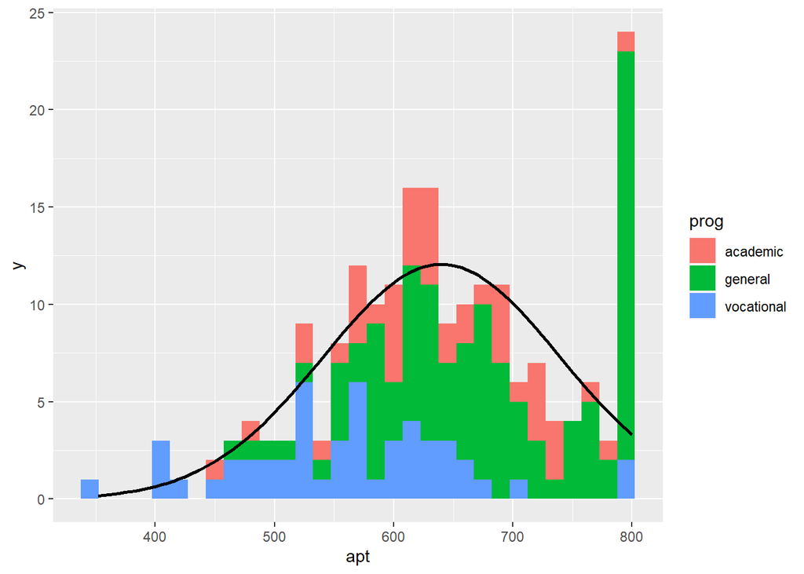

```r
# setup base plot
p <- ggplot(dat, aes(x = apt, fill=prog))

# histogram, coloured by proportion in different programs
# with a normal distribution overlayed
p + stat_bin(binwidth=15) +
stat_function(fun = f, size = 1,
args = list(var = dat$apt))
```

#### Tobit Regression

Looking at the above histogram, we can see the censoring in the values of apt, that is, there are far more cases with scores of 750 to 800 than one would expect looking at the rest of the distribution. Below is an alternative histogram that further highlights the excess of cases where apt=800. In the histogram below, the breaks option produces a histogram where each unique value of apt has its own bar (by setting breaks equal to a vector containing values from the minimum of apt to the maximum of apt).

Because apt is continuous, most values of apt are unique in the dataset, although close to the center of the distribution there are a few values of apt that have two or three cases. The spike on the far right of the histogram is the bar for cases where apt=800, the height of this bar relative to all the others clearly shows the excess number of cases with this value.

```r
p + stat_bin(binwidth = 1) + stat_function(fun = f, size = 1, args = list(var = dat$apt,
bw = 1))
```

[figure not shown]

Next we’ll explore the bivariate relationships in our dataset.

```r
cor(dat[, c("read", "math", "apt")])
```

```
##           read      math       apt
## read 1.0000000 0.6622801 0.6451215
## math 0.6622801 1.0000000 0.7332702
## apt  0.6451215 0.7332702 1.0000000
```

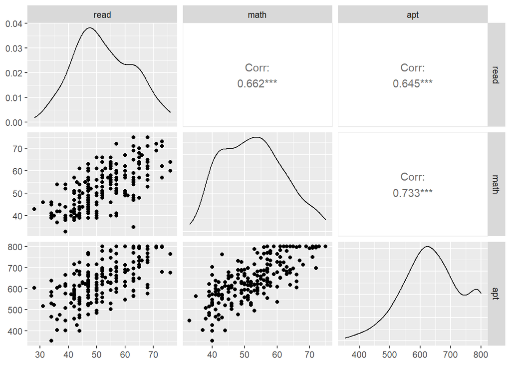

```r
##        read   math    apt
## read 1.0000 0.6623 0.6451
## math 0.6623 1.0000 0.7333
## apt  0.6451 0.7333 1.0000
# plot matrix
ggpairs(dat[, c("read", "math", "apt")])
```